# Computer Problem Set 1

In this present iPython Notebook we will prensent the binomial option pricing model, also called Cox-Ross-Rubinstein model.

## The Cox-Ross-Rubinstein model:

The Black-Scholes formula is the cornerstone for option pricing and has paved the way to more complex derivatives pricing models.

To understand the Black-Schoels model, we must first have a look at the Cox-Ross-Rubinstein model. We will price a **call option** whose payoff is given by:

$$Max\{S(T) - K, 0\}$$

In order to build our model, we will need 7 parameters:

- $S$: The price of the stock today
- $K$: The strike price of the call
- $r$: The risk-free interest rate
- $n$: The number of periods
- $T$: The time to maturity
- $b$: The drift of the stock
- $\sigma$: The volatility of the stock

The up factor and down factor are thus:

$$ u = \exp{(b \, \frac{T}{n} + \sigma \, \sqrt{\frac{T}{n}})}$$$$ d = \exp{(b \, \frac{T}{n} - \sigma \, \sqrt{\frac{T}{n}})}$$

```python
#Importing libraries

import  numpy               as np                   #Arrays and math
from    scipy.special       import comb             #combinatronics
import  scipy.stats         as si                   #Normal distribution
import  seaborn             as sns                  #Good looking plots
import  matplotlib.pyplot   as plt                  #Plot utilities
```

```python
#SETTING GLOBAL PARAMETERS FOR PLT

plt.rcParams['figure.figsize'] = (8.0,4.0)
plt.rcParams.update({'font.size':10})
plt.rcParams['xtick.major.pad'] = '5'
plt.rcParams['ytick.major.pad'] = '5'
plt.style.use('ggplot')
```

```python
#Defining values

S = 100
T = 2
n = 50
r = 0.05
b = 0.05
K = 80
sigma = 0.3
```

Since the stock can go up or down at every period, we need to compute, for $n$ periods, all the possible paths the stock can take. For example, as of July 2016, the price of AAPL is at \$95.889. Let us suppose that we want to sell a call option with strike price at \$97 two months from now. Assuming a two period binomial model and estimating $\sigma \approx 0.26702$ we can infer that the stock can move in any of the following ways:

[figure not shown]

Let's start by building a function that will give us all the possible price outcomes at time $j$ for our stock.

```python
'''
This function is the answer for Q1-a. It returns the array $S^n_j$ of all possible outcomes for the value of the asset at time j.
'''
def Sn(T, n, b, sigma, j, S):

    #Defining h, u and d
    h = T/n
    u = np.exp(b * h + sigma * np.sqrt(h))
    d = np.exp(b * h - sigma * np.sqrt(h))

    #Creating array of zeroes
    Sn = np.zeros(shape = (j+1, 1))

    #loop to fill correct values
    for i in range(j+1):
        Sn[i,0] = S * (u**(j-i)) * (d**i)

    return Sn
```

```python
#Testing for j = 5

Sn(T, n, b, sigma, 5, S)
```

```
array([[136.34251141],
       [120.92495977],
       [107.25081813],
       [ 95.12294245],
       [ 84.36648166],
       [ 74.82635676]])
```

In the Cox-Ross-Rubinstein model, we assume that the final payoff is a martingale process, thus once knowing the possible final states, we can compute its expectation one period before. By iterating this process, we can compute our final option payoff.

This is an implementation in Python:

```python
'''
This function is the answer for Q1-b. It returns the array of all possible outcomes for the payoff for the European call of the underlying asset. The payoff of the European call is defined as $Max{S^n_n - K, 0}$ where K is the strike of the underlying asset.
'''
def Payoffn(T, n, b, sigma, K, S):

    #Create an array of ones then multiply by K
    Strike = K * np.ones((n+1, 1))

    #Difference then maximum (np.maximum docs)
    return np.maximum(Sn(T, n, b, sigma, n, S) - Strike, 0)
```

```python
Payoffn(T, n, b, sigma, K, S)
```

```
array([[2139.79512814],
       [1888.78166448],
       [1666.15269366],
       [1468.69850963],
       [1293.57235851],
       [1138.24939607],
       [1000.49028639],
       [ 878.30891668],
       [ 769.94376289],
       [ 673.83249337],
       [ 588.58944423],
       [ 512.98564186],
       [ 445.93108444],
       [ 386.4590271 ],
       [ 333.71204403],
       [ 286.92966676],
       [ 245.43742029],
       [ 208.63709893],
       [ 175.99814183],
       [ 147.04998375],
       [ 121.37527075],
       [  98.60384308],
       [  78.4073985 ],
       [  60.49475906],
       [  44.60767306],
       [  30.51709181],
       [  18.01986733],
       [   6.93582354],
       [   0.        ],
       [   0.        ],
       [   0.        ],
       [   0.        ],
       [   0.        ],
       [   0.        ],
       [   0.        ],
       [   0.        ],
       [   0.        ],
       [   0.        ],
       [   0.        ],
       [   0.        ],
       [   0.        ],
       [   0.        ],
       [   0.        ],
       [   0.        ],
       [   0.        ],
       [   0.        ],
       [   0.        ],
       [   0.        ],
       [   0.        ],
       [   0.        ],
       [   0.        ]])
```

We can now compute the price of the option using the following formula (using notations from p.25 of the lectures notes):

$$p^n(B^n) = e^{-rT} \, \sum_{j=0}^{n} g(s \, u_n^j \, d_n^{n-j}) \, C^j_n \, q^j_n \, (1 - q_n)^{n-j}$$

The following is an implementation in Python:

```python
'''
This function is a helper function. It returns the array of payoff multiplied (in an elementwise fashion) by the corresponding probability under the measure $\mathbb{Q}$. This is explained in p.25 of the lectures notes.
'''
def ArrayProban(T, n, r, b, sigma):

    #Defining h, u and d
    h = T/n
    u = np.exp(b * h + sigma * np.sqrt(h))
    d = np.exp(b * h - sigma * np.sqrt(h))

    Rn = np.exp(r * h)
    qn = (Rn - d)/(u - d)

    #Creating array of zeroes
    Qn = np.zeros(shape = (n+1, 1))

    #loop to fill correct values
    for i in range(n+1):
        Qn[i,0] = comb(n, i, exact=True) * ((1 - qn)**(i)) * (qn**(n-i))

    return Qn

'''
This function is the answer for Q1-c. It returns the price of the European call for the underlying asset, with Strike K and price at 0 S at maturity T, as defined in p.25 of the lectures notes.
'''
def Calln(T, n, r, b, sigma, K, S):

    #Dot product of the payoff and probabilities arrays to obtain expectation
    #under probability measure Q
    p = np.vdot(Payoffn(T, n, b, sigma, K, S), ArrayProban(T, n, r, b, sigma))

    #We then discount the result with the interest rate R to obtain the price
    #of the European call
    return np.exp(-r*T) * p
```

```python
Calln(T, n, r, b, sigma, K, S)
```

```
32.22152694818203
```

We can now at each time $j \, h_n$ compute the optimal hedging strategy $\theta^n_j$ corresponding to the above European Call option.

Here is a Python function returniing the vector of all hedging strategies at time $j$:

```python
'''
This function is a helper function. It returns the price of the European call for the underlying asset, with Strike K and price at 0 S, at time t.

This is based on a time shift argument:
As defined in p.24 of the lecture notes, the no-arbitrage market price of the contingent claim at t is defined as the expectation operator under probability measure $Q_t-1$ of the the contingent claim. Since this process goes backward in time, we need n-t steps to get to time t.

Thus the no-arbitrage market price of the contingent claim at t is the the no-arbitrage market price of the claim using n-t steps instead of n steps.
'''
def Callt(T, n, r, b, sigma, K, t, S):

    return Calln(T, n-t, r, b, sigma, K, S)

'''
This function is the answer for Q1-d. It returns the array of all possible hedging strategies at time j. This is based on the definitions p.24 of the lectures notes.

To get the array we have to cycle through all the outcomes at time j.
'''
def Deltan(T, n, r, b, sigma, K, j, S):

    #Defining an array of zeros th (for thêta)
    th = np.zeros((j+1, 1))

    #Defining h, u and d
    h = T/n
    u = np.exp(b * h + sigma * np.sqrt(h))
    d = np.exp(b * h - sigma * np.sqrt(h))

    #Sj is the array of possible outcomes at j
    Sj = Sn(T, n, b, sigma, j, S)

    #po is the array of call prices at j+1
    po = [Callt(T, n, r, b, sigma, K, j + 1, Si) for Si in Sn(T, n, b, sigma, j+1, S)]

    #We loop through all possible outcomes to get a strategy for each one
    for each in range(j+1):
        th[each] = (po[each] - po[each + 1]) / (u * Sj[each] - d * Sj[each])

    return th
```

```python
#MEF Max j value is n-2 and min is 0
Deltan(T, n, r, b, sigma, K, 5, S)
```

```
array([[0.95521777],
       [0.92176816],
       [0.87242278],
       [0.80498845],
       [0.71950055],
       [0.61890925]])
```

Let's examine the dependence effect of the strike $K$ on the functions `Calln` and `Deltan`.

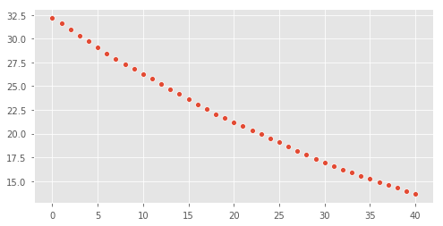

```
'\nWe can see that the call price is a _**decreasing convex**_ function of $K$.\n'
```

```python
'''
The following code is the answer for Q1-e.

Let's examine the dependence effect of the strike $K$ on the functions ``Calln`` and ``Deltan``.
'''

call = [Calln(T, n, r, b, sigma, K + i, S) for i in range(41)]
sns.scatterplot([i for i in range(41)], call)
plt.show()

'''
We can see that the call price is a _**decreasing convex**_ function of $K$.
'''
```

We can see that the call price is a **decreasing convex** function of $K$.

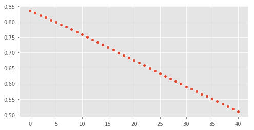

```
'\nWe can see that the Hedging strategy at 0 is a _**decreasing**_ function of $K$. Since all stock prices at time $j$ can be considered starting stock prices for a new binomial tree, the corresponding hedging strategies can be seen as hedging strategies at 0 for these trees.\n\nWe thus obtain that …
```

```python
delta = [Deltan(T, n, r, b, sigma, K + i, 0, S) for i in range(41)]
sns.scatterplot([i for i in range(41)], delta)
plt.show()

'''
We can see that the Hedging strategy at 0 is a _**decreasing**_ function of $K$. Since all stock prices at time $j$ can be considered starting stock prices for a new binomial tree, the corresponding hedging strategies can be seen as hedging strategies at 0 for these trees.

We thus obtain that the hedging strategy at time $j$ is a _**decreasing**_ function of $K$.
'''
```

We can see that the Hedging strategy at 0 is a **decreasing** function of $K$. Since all stock prices at time $j$ can be considered starting stock prices for a new binomial tree, the corresponding hedging strategies can be seen as hedging strategies at 0 for these trees.

We thus obtain that the hedging strategy at time $j$ is a **decreasing** function of $K$.

## The Black-Scholes formula:

Using the lectures notes we know that the Cox-Ross-Rubinstein model is a discrete time approximation of the Black-Scholes continious time model where the risky asset has a log-normal distribution. The price of the European call option is therefore given by:

$$p(B) = S \, N\bigg(d_+(S, \frac{K}{e^{rT}}, \sigma^2 T)\bigg) - \frac{K}{e^{rT}} \, N\bigg(d_-(S, \frac{K}{e^{rT}}, \sigma^2 T)\bigg)$$

Where $N$ is the cumulative distribution function of a standard Gaussian $\mathcal{N}(0,1)$ and $d_\pm$ is given by:

$$d_\pm(s, k, v) = \frac{ln(s\,/\,k)}{\sqrt{v}} \pm \frac{\sqrt{v}}{2}$$

The following is an implementation in Python:

```python
'''
This function is the answer for Q2-a. It returns the Black_Scholes price at time 0 of the European call option.

This is based on the Theorem 2.8 of p.26 of the lecture notes.
'''
def Call(T, r, sigma, K, S):

    #defining the d+ and d- functions
    dp = (np.log(S / K) + (r + 0.5 * sigma ** 2) * T) / (sigma * np.sqrt(T))
    dm = (np.log(S / K) + (r - 0.5 * sigma ** 2) * T) / (sigma * np.sqrt(T))

    #The call price is therefore
    call = (S * si.norm.cdf(dp, 0.0, 1.0) - K * np.exp(-r * T) * si.norm.cdf(dm, 0.0, 1.0))

    return call
```

```python
Call(T, r, sigma, K, S)
```

```
32.19291006531836
```

We can also define the error of the Cox-Ross-Rubinstein model to its Black-Scholes limit:

```python
'''
This function is the answer for Q2-b. It returns the relative error between the Black_Scholes price at time 0 of the European call option and the Cox-Ross-Rubinstein one.
'''
def err(T, n, r, b, sigma, K, S):

    cox = Calln(T, n, r, b, sigma, K, S)
    bsm = Call(T, r, sigma, K, S)

    return cox/bsm - 1
```

```python
err(T, n, r, b, sigma, K, S)
```

```
0.0008889187962695111
```

```python
'''
The following code is the answer for Q2-b.

Let's examine the dependence effect of the strike $K$ on the functions ``Calln`` and ``Deltan``.
'''

#Redefining values

S = 100
T = 2
r = 0.05
b = 0.05
K = 105
sigma = 0.3
N = 201
```

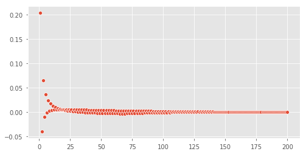

```
'\nWe can see that the Cox-Ross-Rubinstein model converges relatively quickly (the error nears 0). And for n values superior to 100 the error is nearly zero.\n'
```

```python
call = [err(T, i, r, b, sigma, K, S) for i in range(1, N)]
sns.scatterplot([i for i in range(1, N)], call)
plt.show()

'''
We can see that the Cox-Ross-Rubinstein model converges relatively quickly (the error nears 0). And for n values superior to 100 the error is nearly zero.
'''
```

We can see that the Cox-Ross-Rubinstein model converges relatively quickly (the error nears 0). And for n values superior to 100 the error is nearly zero.